# Data Visualization with Python

## [建議].先行將seaborn update到0.9版

- pip3 install seaborn==0.9.0

## [基本說明]. Visualization of seaborn

- #### seaborn是一個建立在matplot之上，可用於製作豐富和非常具有吸引力統計圖形的Python庫。
- #### Seaborn旨在將可視化作爲探索和理解數據的核心部分，有助於幫人們更近距離了解所研究的數據集。

[figure not shown]

## [前置作業].matplotlib 與 seaborn 中文顯示問題

### Python資料視覺化主要有三大套件：

- 'Matplotlib': 指令功能齊全，歷史最悠久的套件，己乎沒有圖示畫不出來的，但也最複雜
- 'Seaborn': 是在Matplot的基礎上實作更高階的視覺化API，可以讓畫圖變得更方便、容易。
- 'Plotly': 好看的各種視覺化圖表，可做出互動化的介面。但Plotly並沒有在Anaconda裡面，所以要在先下pip install plotly進行安裝

### 字形編碼問題

- 在matplotlib 或 Seaborn 中，對於中文必須特別設定，否則圖不會顯示中文
- 請採用以下設定，請參考

https://medium.com/marketingdatascience/%E8%A7%A3%E6%B1%BApython-3-matplotlib%E8%88%87seaborn%E8%A6%96%E8%A6%BA%E5%8C%96%E5%A5%97%E4%BB%B6%E4%B8%AD%E6%96%87%E9%A1%AF%E7%A4%BA%E5%95%8F%E9%A1%8C-f7b3773a889b

- 建議:
  - Mac可用字體：SimHei
  - Windows 可用字體：Microsoft JhengHei

### STEP1: 先用以下程式碼找到目前字體路徑，確認目前是抓哪個字體

```python
from matplotlib.font_manager import findfont, FontProperties
findfont(FontProperties(family=FontProperties().get_family()))
```

```
'C:\\Users\\user\\Anaconda3\\lib\\site-packages\\matplotlib\\mpl-data\\fonts\\ttf\\DejaVuSans.ttf'
```

### STEP2:使用以下程式碼去尋找設定檔路徑

```python
import matplotlib
matplotlib.matplotlib_fname()
```

```
'C:\\Users\\user\\Anaconda3\\lib\\site-packages\\matplotlib\\mpl-data\\matplotlibrc'
```

- 1.找出 C:\Users\user\Anaconda3\lib\site-packages\matplotlib\mpl-data\matplotlibrc 檔案，然後用記事本打開
- 2.將font.family與font.serif註解(#)移除，並在font.serif後方加入Microsoft JhengHei

[figure not shown]

### STEP3: 刪除.matplotlib快取資料夾

- 然後刪除.matplotlib 資料夾，因為.matplotlib 資料夾裡面有舊有的matplotlib 快取(cache)檔案，為避免更新後的字體在讀取到舊的快取，所有要刪除。

[figure not shown]

### STEP4:放入字體至matplotlib指定字體路徑

- 將msj文字檔(載點，為其他網友提供)下載，以msj命名之，在儲存到以下路徑資料夾 ： C:\Users\您的使用者名稱\Anaconda3\Lib\site-packages\matplotlib\mpl-data\fonts\ttf

[figure not shown]

### STEP5: 使用rcParams 參數指定字體

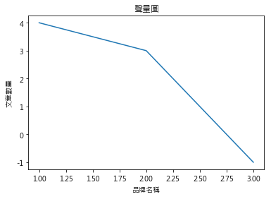

```python
#測試一下
%matplotlib inline
##將後續畫圖的結果直接顯現在網頁中

import numpy as np
import matplotlib.pyplot as plt
import pandas as pd
import seaborn as sns #加入seaborn套件

from matplotlib.font_manager import FontProperties
import matplotlib.pyplot as plt
plt.rcParams['font.sans-serif'] = ['Microsoft JhengHei']
plt.rcParams['axes.unicode_minus'] = False
plt.plot((1,2,3),(4,3,-1))
plt.title("聲量圖")
plt.ylabel("文章數量")
plt.xlabel("品牌名稱")
plt.show()
```

## [標準開始動作]. 如果你用python的目標是科學計算或數值分析，基本是引⼊三個套件

```python
%matplotlib inline
##將後續畫圖的結果直接顯現在網頁中

import numpy as np
import matplotlib.pyplot as plt
import pandas as pd

import seaborn as sns #加入seaborn套件
```

## [Part 1]. 基本敘述性統計

tips(小費)數據集。小費數據集，是一個餐廳侍者收集的關於小費的數據，其中包含了七個變量，包括

- total_bill: 總費用
- tip: 付小費的金額
- sex: 付款者性別
- smoker: 是否吸菸
- day: 日期
- time: 給小費的時段
- size: 顧客人數。

#### [主要分析目的]. 通過數據分析和建模，可幫助餐廳侍者預測來餐廳就餐的顧客是否會會支付小費。

```python
tips = pd.read_csv('tips.csv')
```

```python
tips.head() #看前五筆資料
```

|  | total_bill | tip | sex | smoker | day | time | size |
| --- | --- | --- | --- | --- | --- | --- | --- |
| 0 | 16.99 | 1.01 | Female | No | Sun | Dinner | 2 |
| 1 | 10.34 | 1.66 | Male | No | Sun | Dinner | 3 |
| 2 | 21.01 | 3.50 | Male | No | Sun | Dinner | 3 |
| 3 | 23.68 | 3.31 | Male | No | Sun | Dinner | 2 |
| 4 | 24.59 | 3.61 | Female | No | Sun | Dinner | 4 |

```python
tips.tail() #看後面幾筆
```

|  | total_bill | tip | sex | smoker | day | time | size |
| --- | --- | --- | --- | --- | --- | --- | --- |
| 239 | 29.03 | 5.92 | Male | No | Sat | Dinner | 3 |
| 240 | 27.18 | 2.00 | Female | Yes | Sat | Dinner | 2 |
| 241 | 22.67 | 2.00 | Male | Yes | Sat | Dinner | 2 |
| 242 | 17.82 | 1.75 | Male | No | Sat | Dinner | 2 |
| 243 | 18.78 | 3.00 | Female | No | Thur | Dinner | 2 |

```python
tips.describe() #基本統計量，只會列出屬"量"資料
```

|  | total_bill | tip | size |
| --- | --- | --- | --- |
| count | 244.000000 | 244.000000 | 244.000000 |
| mean | 19.785943 | 2.998279 | 2.569672 |
| std | 8.902412 | 1.383638 | 0.951100 |
| min | 3.070000 | 1.000000 | 1.000000 |
| 25% | 13.347500 | 2.000000 | 2.000000 |
| 50% | 17.795000 | 2.900000 | 2.000000 |
| 75% | 24.127500 | 3.562500 | 3.000000 |
| max | 50.810000 | 10.000000 | 6.000000 |

## [Part 2]. Visualization to EDA

- Seaborn 套件是以 matplotlib 為基礎建構的高階繪圖套件，讓使用者更加輕鬆地建立圖表，我們可以將它視為是 matplotlib 的補強

```python
sns.set(style="ticks")
```

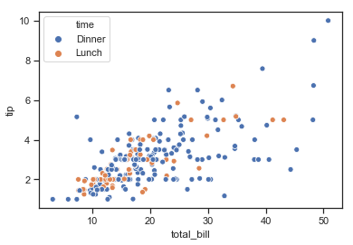

```python
sns.scatterplot(x="total_bill", y="tip",
                hue="time",
                data=tips)
```

### 2-1.次數分配圖

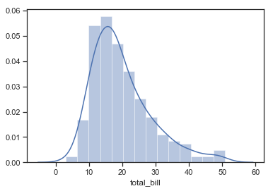

```python
sns.distplot(tips['total_bill'])
```

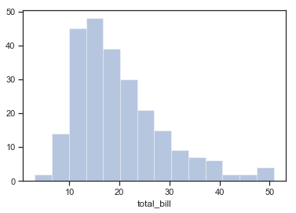

```python
sns.distplot(tips['total_bill'],kde = False) # kde = Kernel Density
```

### 上圖顯示，顧客在餐廳的消費總金額主要是在5-35的範圍內分佈的(右偏分佈)

### 2-2.count plot

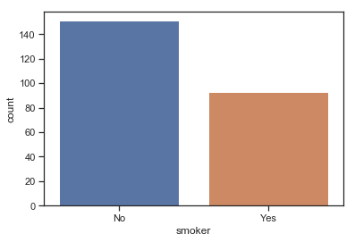

```python
sns.countplot(x = 'smoker',  data = tips)
```

### 來餐廳就餐的顧客，不抽菸者比會抽菸者多

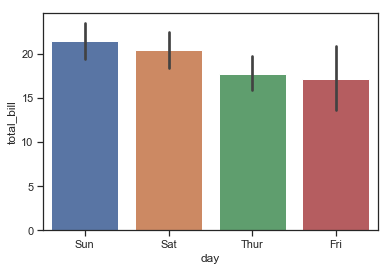

```python
sns.barplot(x="day", y="total_bill", data=tips)
```

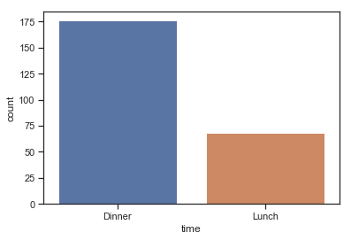

```python
sns.countplot(x = 'time',  data = tips)
```

### 顧客來餐廳就餐，主要是來晚飯多一些，來吃午餐的總次數更少一些

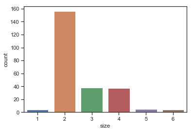

```python
sns.countplot(x = 'size',  data = tips)
```

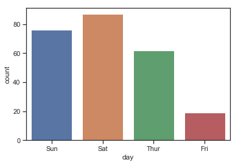

```python
sns.countplot(x = 'day',  data = tips)
```

### 消費次數來說，週六最高

## 2-3. Bar-plot

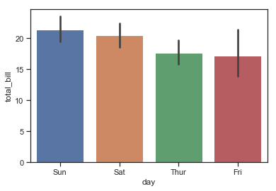

```python
sns.barplot(x="day", y="total_bill", data=tips)
```

### 但顧客主要是週日、週六、週四來餐廳就餐，但消費金額是周日最高

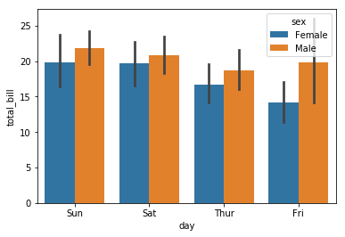

```python
sns.barplot(x="day", y="total_bill", hue="sex", data=tips)
```

### 就餐時消費的賬單，這家餐廳男性的消費較多(男性買單的次數會比由女性買單的次數多一些)

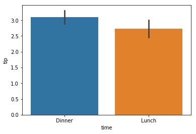

```python
sns.barplot(x="time", y="tip", data=tips,
            order=["Dinner", "Lunch"])
```

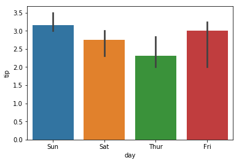

```python
from numpy import median
sns.barplot(x="day", y="tip", data=tips, estimator=median) #用每天的中位數去估計小費的高低
```

## [Part 3].較進階的語法

語法參考 https://seaborn.pydata.org/generated/seaborn.jointplot.html

kind : { “scatter” | “reg” | “resid” | “kde” | “hex” }, optional

Kind of plot to draw.

## 3-1. Joint-Plot

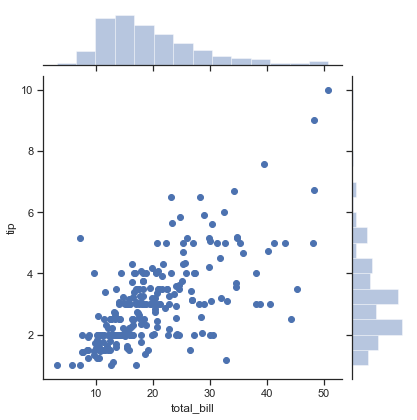

```python
sns.jointplot(x = 'total_bill', y = 'tip', data = tips)
```

- ### 顧客主要消費在10-30元之間，
- ### 對應給侍者小費的錢在1-5元之間

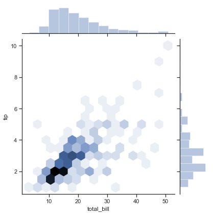

```python
sns.jointplot(x = 'total_bill', y = 'tip', data = tips,kind = 'hex' ) # 清晰地視覺化視圖，顏色的深度代表頻率
```

- ### 消費總金額集中在10-20元之間，小費集中在1-3.5元之間
- ### 但這並不能證明"消費金額越高，小費就給的越多"

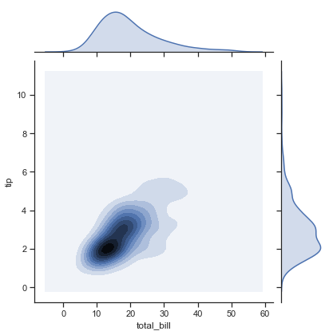

```python
sns.jointplot(x = 'total_bill', y = 'tip', data = tips ,kind = 'kde')
```

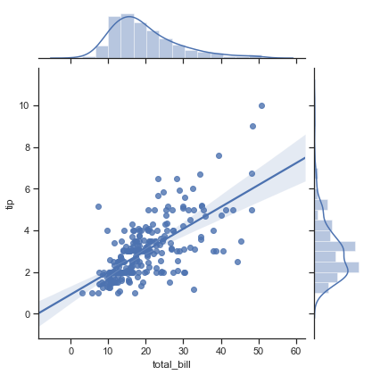

```python
sns.jointplot(x = 'total_bill', y = 'tip', data = tips ,kind = 'reg')
```

### 做一條簡單的迴歸線，它表明了小費的金額是隨着總賬單金額的增加而增加的

## 3-2.Pair-plot

### 我們可看不同變數之間的散佈圖狀況

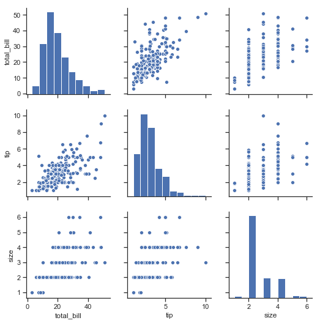

```python
sns.pairplot(tips)
```

### 數據集中在"消費總額、小費金額以及顧客數量"三個變量之間

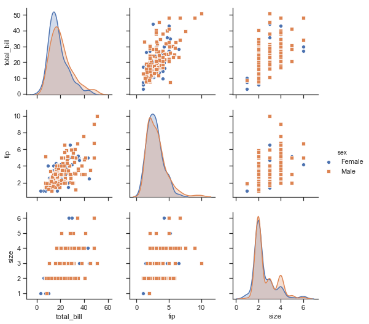

```python
sns.pairplot(tips ,hue ='sex', markers=["o", "s"]) #o是圓圈，s是方塊
#看看性別在不同變數間的關係
# hue ='sex' 以性別當圖標
```

- ### 使用兩種不同的顏色用於區分性別
- ### 這間餐廳的男性顧客較多，但性別是否造成給小費高低的差別，目前無法辨識

## 3-3. Box-plot

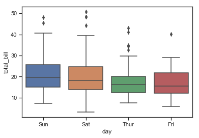

```python
sns.boxplot(x = 'day', y= 'total_bill', data = tips)
```

### 大部分賬單是在週六和週日支付的

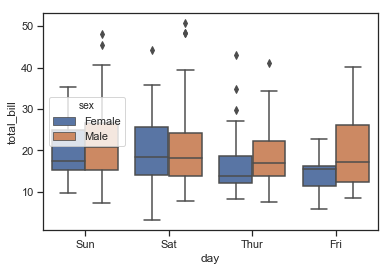

```python
sns.boxplot(x = 'day', y= 'total_bill', data = tips, hue = 'sex') # hue = 'sex'以性別當圖標
```

## 3-4.Cat-Plot

```python
sns.set(style="ticks", color_codes=True)
```

```python
help(sns.catplot)
```

[output not shown]

[output cut: 141 more lines]

[output not shown]

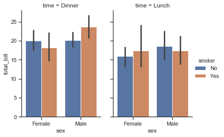

```python
sns.catplot(x="sex", y="total_bill",
            hue="smoker", col="time",
            data=tips, kind="bar",
            height=4, aspect=.7)
```

資料來源: https://www.smwenku.com/a/5b858ea82b71775d1cd31628